# OLX Car Price Scraper

Dan S. Reznik

Abril, 2019

### Load libraries

```r
library(magrittr)
library(tidyverse)
library(rvest)
library(ggvis)
library(glue)
library(ggridges)
library(xlsx)
library(fs)
library(tictoc)
source("olx_scraper_utils.R")
```

To refresh scrape must delete both .rds below from disk

```r
fname_advert <- "advert_df_pp.rds"
advert_exists <- file_exists(fname_advert)
```

## Scraping

Inspired by this [article](https://www.analyticsvidhya.com/blog/2017/03/beginners-guide-on-web-scraping-in-r-using-rvest-with-hands-on-knowledge/)

Construct DF with brand, model, pages, and subpages

```r
urls_1_df <- tribble(
  ~brand, ~model,
  "honda", "civic",
  "toyota", "corolla",
  "nissan", "sentra",
  "vw-volkswagen", "jetta",
  "renault", "fluence") %>%
  mutate(url=olxURL(brand,model),
         subpages=map(url, ~.x %>%
                        read_html() %>%
                        getPageNumbers))
```

Cleans the “integer(0)” when there’s only the 1st page, unnest to make a separate row for each subpage, and compute url’s of subpages:

```r
urls_complete <- urls_1_df %>%
  mutate(subpages=map(subpages,
                      ~(if(length(.x)==0) 1L else .x))) %>%
  unnest(subpages) %>%
  mutate(url_subpage=olxURL_page(brand,model,subpages))
```

Get pages, slow hits webserver

```r
tic()
urls_complete %<>% mutate(page=get_html_pages(urls_complete$url_subpage))
toc()
```

```
#> 119.956 sec elapsed
```

### Build dataframe for links, title, prices for all ads

```r
advert_df0 <- urls_complete %>%
  mutate(link=get_html_href(page,".OLXad-list-link"),
         title=get_html_text(page,".OLXad-list-title"),
         price=get_html_text(page,".OLXad-list-price") %>% map(convertReais),
         region=get_html_text(page,".detail-region") %>%
           map(~str_replace_all(.x,"[\\s\\n\\t]+"," ")),
         kcm=get_html_text(page,".detail-specific") %>%
           map(decodeKmCambioMotor))

# does this to adjust all list-columns to a max number of items
# which is equal to the min of all link,title,prince,region,kcm
max_items0 <- advert_df0%>%
  select_if(is.list)%>%
  map(~map_int(.x,length))%>%
  as_tibble%>%
  mutate(max_items=pmap_int(list(link,title,price,region,kcm),
                            ~min(..1,..2,..3,..4,..5)))

advert_df <- advert_df0 %>%
  mutate_at(vars(link,title,price,region,kcm),
            ~map2(.,max_items0$max_items,~head(.x,.y))) %>%
  unnest(link,title,price,region,kcm,.preserve=page) %>%
  separate(kcm,into=c("km","cambio","motor"),"\\|",convert=T)
```

Post process advert_df

```r
advert_df_pp <- advert_df %>%
  transmute(brand=as.factor(brand), model=as.factor(model),
            year=title %>% str_sub(start=-4) %>% as.integer() %>% as.factor(),
            title=str_sub(title,end=-7),
            ddd=str_sub(region,start=-2),
            region=str_replace(region," - DDD \\d\\d",""),
            price1k=round(price/1000,1),
            km1k=round(km/1000,1),
            cambio=as.factor(cambio),
            motor=as.factor(motor),
            link)
```

Recursively get car description from linked page. Slow (hits webserver many times)

```r
if(!advert_exists) advert_df_pp %<>%
  mutate(pages_descr=get_html_pages(link))
```

```r
if(!advert_exists)
  advert_df_pp %<>%
  mutate(descr=unlist(get_html_text_collapse(pages_descr,
                                             ".OLXad-description")),
         model_descr=unlist(get_html_text(pages_descr,".model")))
```

```r
if(!advert_exists)
  write_rds(advert_df_pp,fname_advert,compress = "bz")
```

### Limpeza da descrição e modelo

A partir daqui só precisa de advert_df_pp

```r
advert_df_pp <- read_rds(fname_advert)
```

```r
advert_df_pp_clean <- advert_df_pp %>%
  mutate(key=row_number(),
         descr=descr %>% str_to_lower() %>% str_replace_all("[^[:alnum:]/]"," ") %>%
           str_replace_all("\\s{2,}"," "),
         model_descr=str_replace(model_descr,"Modelo:[\\n\\t]+","") %>%
           str_replace("AUTOM[AÁ]TICO","AUT.") %>%
           str_replace("(SED.|SEDAN|UPPER) ","") %>%
           str_replace("FLEX\\s?(START|FUEL|ONE)","FLEX"))
```

Reporta preço mediano e N por modelo. Parece q modelos são padronizados tipo FIPE

```r
advert_df_pp_clean_counts <- advert_df_pp_clean %>%
  group_by(model) %>%
  summarize(N=n(),price1k_median=median(price1k)) %>%
  arrange(desc(price1k_median)) %>%
  ungroup() %T>% print
```

```
#> # A tibble: 5 x 3
#>   model       N price1k_median
#>   <fct>   <int>          <dbl>
#> 1 corolla   251           72.9
#> 2 jetta     390           72
#> 3 civic     596           65.9
#> 4 sentra    147           62.8
#> 5 fluence   218           52.9
```

```r
advert_df_pp_clean_counts <- advert_df_pp_clean %>%
  #mutate(model=compressModel(model) %>% str_replace_all("\n"," ")) %>%
  group_by(brand,model) %>%
  summarize(N=n(),price1k_median=median(price1k)) %>%
  arrange(desc(price1k_median)) %>%
  ungroup() %T>% print
```

```
#> # A tibble: 5 x 4
#>   brand         model       N price1k_median
#>   <fct>         <fct>   <int>          <dbl>
#> 1 toyota        corolla   251           72.9
#> 2 vw-volkswagen jetta     390           72
#> 3 honda         civic     596           65.9
#> 4 nissan        sentra    147           62.8
#> 5 renault       fluence   218           52.9
```

Modelos mais frequentes

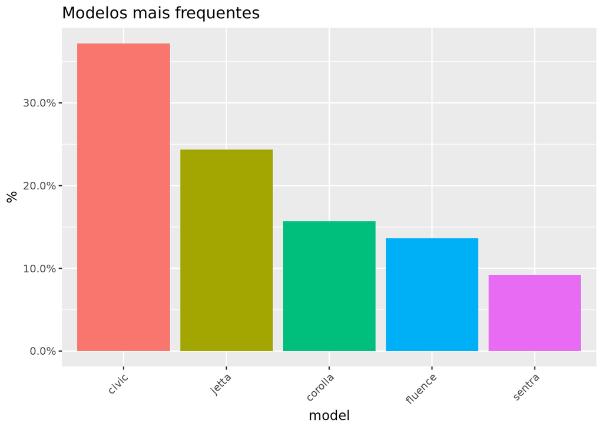

```r
advert_df_pp_clean %>%
  mutate(model = model %>% fct_infreq() %>% fct_lump(5)) %>%
  ggplot(aes(x=model,fill=model)) +
  #geom_bar(stat="count") +
  geom_bar(aes(y = (..count..)/sum(..count..))) +
  scale_y_continuous(labels=scales::percent) +
  labs(y="%",title="Modelos mais frequentes")+
  theme(axis.text.x = element_text(angle = 45, hjust = 1),
        legend.position = "none")
```

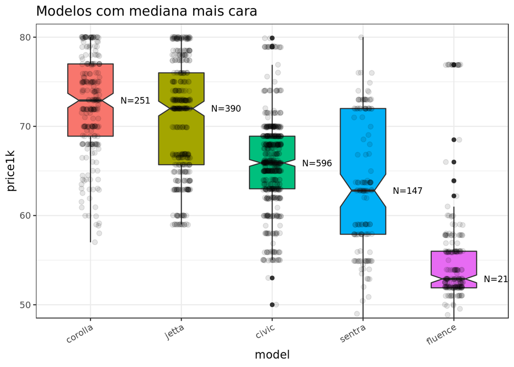

```r
fun_length_y <- function(x) data.frame(y=median(x),label= paste0("N=", length(x)))

advert_df_pp_clean %>%
  mutate(model = model %>% fct_lump(8) %>%
           fct_reorder(price1k,.desc=T)) %>%
  filter(model!="Other") %>%
  ggplot(aes(x=model,y=price1k,fill=model)) +
  #geom_bar(stat="count") +
  geom_boxplot(width=.5,notch=T) +
  stat_summary(fun.data = fun_length_y,
               geom = "text", vjust = .5,hjust=-1, size = 3) +
  geom_jitter(color="black",alpha=.1,width=.1,size=2) +
  theme_bw() +
  coord_cartesian(ylim=c(50,80)) +
  labs(title="Modelos com mediana mais cara")+
  theme(axis.text.x = element_text(angle = 30, hjust = 1),
        legend.position = "none")
```

```r
ggsave("most_expensive.png",width=10,height=5,units="in")
```

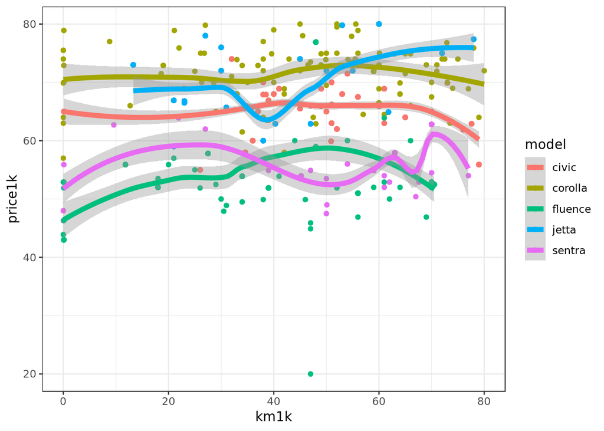

```r
advert_df_pp_clean %>%
  filter(!is.na(km1k),!is.na(price1k)) %>%
  filter(year==2016) %>%
  ggplot(aes(x=km1k,y=price1k,color=model)) +
  geom_point() +
  geom_smooth(size=2) +
  theme_bw()
```

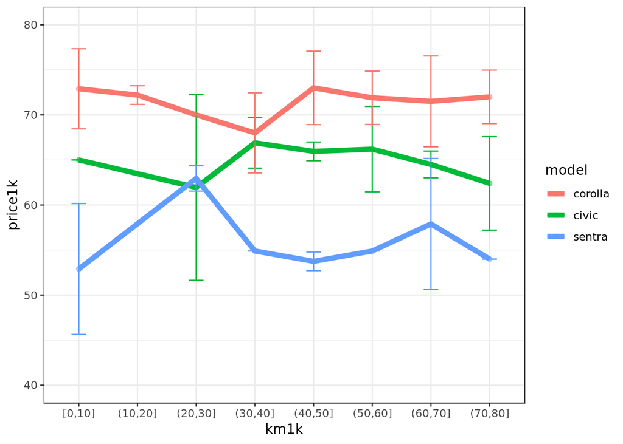

```r
advert_df_pp_clean %>%
  filter(year==2016,!is.na(km1k),
         model %in% c("civic","corolla","sentra")) %>%
  mutate(km1k=km1k %>% cut_width(10,boundary=0)) %>%
  group_by(model,km1k) %>%
  summarize(price1k_mad=mad(price1k),
            price1k=median(price1k) # must be 2nd as prev result needs it
            ) %>%
  ungroup() %>%
  mutate(model=model%>%fct_reorder(price1k,.desc=T)) %>%
  ggplot(aes(x=km1k,y=price1k)) +
  geom_line(aes(group=model,color=model),size=2) +
  geom_errorbar(aes(x=km1k,ymin=price1k-price1k_mad,ymax=price1k+price1k_mad,
                    group=model,color=model),width = 0.25) +
  geom_point(aes(color=model),alpha=.5) +
  coord_cartesian(ylim=c(40,80)) +
  theme_bw()
```

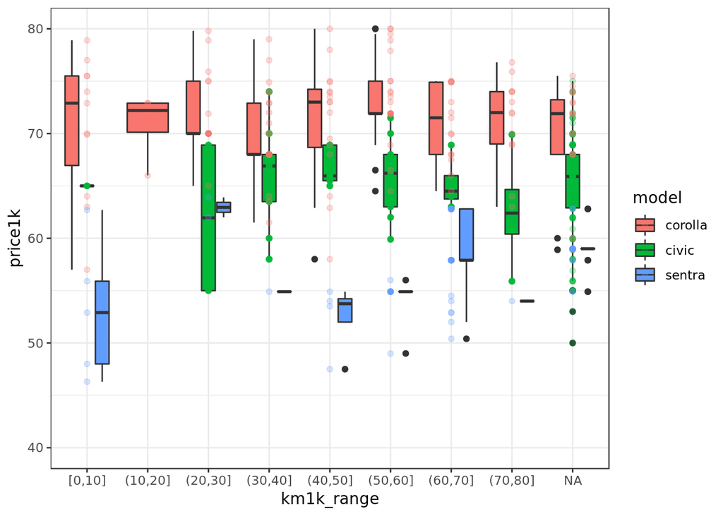

```r
advert_df_pp_clean %>%
  filter(year==2016,model %in% c("civic","corolla","sentra")) %>%
  mutate(km1k_range=km1k %>% cut_width(10,boundary=0),
         model=model%>%fct_reorder(price1k,.desc=T)) %>%
  ggplot(aes(x=km1k_range,y=price1k)) +
  geom_boxplot(aes(fill=model)) +
  geom_point(aes(color=model),alpha=.25) +
  coord_cartesian(ylim=c(40,80)) +
  theme_bw()
```

## Sentiment Analysis

Para cada carro (identificado por “key”), liste as palavras usadas na descrição.

```r
advert_df_pp_words <- advert_df_pp_clean %>%
  select(key,descr) %>%
  mutate(word=str_split(descr,"\\s+")) %>%
  select(-descr) %>%
  unnest() %>%
  filter(str_length(word)>2,
         !str_detect(word,"\\d"))
```

Estudo frequencial das palavras

```r
advert_df_pp_words_counted <- advert_df_pp_words %>%
  count(word,sort=T) %T>% print
```

```
#> # A tibble: 2,349 x 2
#>    word           n
#>    <chr>      <int>
#>  1 carro       1372
#>  2 com         1298
#>  3 ver          857
#>  4 número       847
#>  5 para         529
#>  6 sem          496
#>  7 ipva         476
#>  8 dono         473
#>  9 couro        468
#> 10 automático   443
#> # … with 2,339 more rows
```

Salvamos em excel para manualmente marcarmos palavras com sentimento negativo

```r
advert_df_pp_words_counted %>%
  as.data.frame() %>%
  write.xlsx("advert_df_pp_words_counted.xls", row.names=F)
```

Le arquivo com palavras com sentimento negativo

```r
df_suspicious <- read_csv("suspicious words.csv") %T>% print
```

```
#> # A tibble: 36 x 1
#>    word
#>    <chr>
#>  1 nunca
#>  2 entrada
#>  3 leilão
#>  4 seguradora
#>  5 avaria
#>  6 bateu
#>  7 batida
#>  8 furto
#>  9 nenhuma
#> 10 parcelada
#> # … with 26 more rows
```

Acha anuncios q contem palavra negativa

```r
advert_df_pp_words_negative <- advert_df_pp_words %>%
  semi_join(df_suspicious,by="word") %>%
  group_by(key) %>%
  summarize(negativity_count=n(),
            bad_words=paste0(word,collapse=","))
```

Expande df de anúncios com análise de sentimento

```r
advert_df_pp_clean_sentiment <- advert_df_pp_clean %>%
  left_join(advert_df_pp_words_negative,by="key") %>%
  mutate(negativity_count=if_else(is.na(negativity_count),0L,negativity_count)) %>%
  arrange(desc(negativity_count))
head(advert_df_pp_clean_sentiment,100)
```

| brand | model | year | title | ddd | region | price1k | km1k | cambio | motor | link | pages_descr | descr | model_descr | key | negativity_count | bad_words |
| --- | --- | --- | --- | --- | --- | --- | --- | --- | --- | --- | --- | --- | --- | --- | --- | --- |
| toyota | corolla | 2017 | Toyota Corolla XEI 1.8 Automático C/Couro e Multimídia | 21 | Rio de Janeiro, Madureira | 67.7 | 0.0 | automático | Flex | https://rj.olx.com.br/rio-de-janeiro-e-regiao/autos-e-pecas/carros-vans-e-utilitarios/toyota-corolla-xei-1-8-automatico-c-couro-e-multimidia-605363058 |  | valores reais anunciamos e garantimos financiamentos no cdc entrada 1 389 77 mensais no carnê fixo não tem vrg resíduo não tem intermediária não é leasing am arrendamento mercantil condições anunciada… | TOYOTA 2.0 XEI 16V FLEX 4P AUT. | 655 | 14 | entrada,feirão,seguradora,leilão,financiamento,juros,financeiras,juros,cartão,crédito,crédito,crédito,entrada,entrada |
| toyota | corolla | 2016 | Toyota Corolla 2016 Upper excelente estado com somente 12.700km rodados | 21 | Rio de Janeiro, Barra da Tijuca | 66.0 | 12.7 | automático | Flex | https://rj.olx.com.br/norte-do-estado-do-rio/autos-e-pecas/carros-vans-e-utilitarios/toyota-corolla-607406757 |  | corolla xei 2016 prata muito novo opcionais ar condicionado direção hidraulica trava eletrica alarme vidro eletricos nas 4 portas computador de bordo camera de ré multimidia controle de som e telefone… | TOYOTA COROLLA XEI 2.0 FLEX 16V AUT. | 602 | 12 | entrada,seguradora,leilão,financiamento,juros,crédito,financeiras,entrada,financeiras,financeira,crédito,crédito |
| renault | fluence | 2017 | Renault Fluence | 21 | Nova Iguaçu, Jardim Império | 41.3 | NA | NA | NA | https://rj.olx.com.br/rio-de-janeiro-e-regiao/autos-e-pecas/carros-vans-e-utilitarios/renault-fluence-598326288 |  | lions seminovos atributos que você encontra somente na lions carros inspecionados e revisados valor anunciado referente ao valor financiado pequena entrada garantia de quilometragem real excelente ate… | RENAULT FLUENCE | 1385 | 12 | entrada,crédito,juros,nenhuma,batida,fumante,entrada,crédito,juros,nenhuma,batida,fumante |
| toyota | corolla | 2016 | Corolla GLI 1.8 | 24 | Volta Redonda, Aterrado | 68.9 | 77.0 | automático | Flex | https://rj.olx.com.br/rio-de-janeiro-e-regiao/autos-e-pecas/carros-vans-e-utilitarios/toyota-corolla-xei-2-0-completo-couro-multimidia-e-gnv-604119475 |  | bruno maia 021 97012 4203 ver número ver número responsável pela aprovação e análise de crédito da loja grande feirão da brother veículos planos de financiamento com parcelas fixas e as menores taxas … | TOYOTA COROLLA XEI 2.0 FLEX 16V AUT. | 641 | 10 | crédito,feirão,financiamento,entrada,cartão,crédito,crédito,leilão,entrada,crédito |
| nissan | sentra | 2017 | Nissan Sentra 2017 SV Automático | 21 | São Gonçalo, Colubande | 68.0 | 55.0 | automático | Flex | https://rj.olx.com.br/rio-de-janeiro-e-regiao/autos-e-pecas/carros-vans-e-utilitarios/sentra-s-2-0-2017-automatico-completo-instalacao-de-gnv-gratis-2019-596900608 |  | lunna car multimarcas consultora de vendas luiz felipe telefone 96713 2304 ver número disponível no whatsapp vendo sentra s 2 0 2017 automático conpleto instalação de gnv ipva grátis entrada r 17 000 … | NISSAN SENTRA 2.0/ 2.0 FLEX 16V AUT. | 893 | 10 | entrada,entrada,crédito,crédito,financeira,financiamento,entrada,entrada,leilão,seguradora |
| honda | civic | 2016 | Honda Civic Lxr 2016/com 40.000km | 21 | Rio de Janeiro, Madureira | 60.9 | NA | NA | NA | https://rj.olx.com.br/rio-de-janeiro-e-regiao/autos-e-pecas/carros-vans-e-utilitarios/honda-civic-lxr-2016-com-40-000km-594096428 |  | bem vindo a 242 veículos motorista de uber venha ser seu patrão veículo super conservado com pneus pintura e interior tudo 100 ok todos os nossos veículos saem revisado e com garantia de motor e caixa… | HONDA CIVIC LXR 2.0 FLEX 16V AUT. 4P | 2 | 9 | entrada,entrada,entrada,cartão,crédito,entrada,entrada,financiamento,crédito |
| honda | civic | 2016 | Civic LXR ( entrada de 10 mil + 60x 1.437,25 ) 2016 | 21 | Rio de Janeiro, Madureira | 53.0 | NA | NA | NA | https://rj.olx.com.br/rio-de-janeiro-e-regiao/autos-e-pecas/carros-vans-e-utilitarios/civic-lxr-entrada-de-10-mil-60x-1-437-25-2016-601407073 |  | honda civic lxr 2 0 aut flexone automatico entrada de 10 mil 1 437 25 mensais fixas acrescente mais r 65 00 na sua parcela e sai com gnv instalado pela loja não trabalhamos com veiculo de leilão ex ta… | HONDA CIVIC LXR 2.0 FLEX 16V AUT. 4P | 22 | 9 | entrada,leilão,seguradora,entrada,entrada,cartões,financiamento,entrada,financiamento |
| toyota | corolla | 2016 | Toyota corolla 2016 xei com 50.000 km | 21 | Rio de Janeiro, Méier | 69.5 | 50.0 | automático | Flex | https://rj.olx.com.br/rio-de-janeiro-e-regiao/autos-e-pecas/carros-vans-e-utilitarios/toyota-corolla-altis-2-0-automatico-entrada-a-partir-de-13-000-00-1-299-99-fixas-no-cdc-601329126 |  | leia toda a descrição do anúncio mega feirão tróia veículos ligue agora procurar o vendedor rony 21 9663452 ver número 66 claro whatsapp 21 9832267 ver número 77 tim whatsapp aprovamos seu crédito por… | TOYOTA COROLLA ALTIS 2.0 FLEX 16V AUT. | 614 | 9 | feirão,crédito,crédito,financeiras,entrada,cartão,crédito,entrada,entrada |
| toyota | corolla | 2016 | Corolla xei 2.0 flex 16v aut | 24 | Volta Redonda, Santo Agostinho | 74.0 | 72.5 | automático | Flex | https://rj.olx.com.br/rio-de-janeiro-e-regiao/autos-e-pecas/carros-vans-e-utilitarios/toyota-corolla-2018-automatico-muito-novo-ipva-2019-pg-603737560 |  | veiculos totalmente revisados com garantia parcelamos sua entrada em ate 10x no cartão de crédito em ate 20 do valor total do veiculo temos mais de 1 500 veículos em estoque veículos único dono impecá… | TOYOTA COROLLA GLI 1.8 FLEX 16V AUT. | 630 | 9 | entrada,cartão,crédito,financiamento,entrada,financeiras,financiamento,entrada,entrada |
| toyota | corolla | 2016 | Toyota Corolla Xei 2.0 Automático Flex 2016 Gnv 5º Geração | 21 | Rio de Janeiro, Colégio | 68.9 | 42.0 | automático | Gás Natural | https://rj.olx.com.br/rio-de-janeiro-e-regiao/autos-e-pecas/carros-vans-e-utilitarios/corolla-gli-2016-automatico-muito-novo-594150693 |  | bem vindo a 242 veículos motorista de uber venha ser seu patrão veículo super conservado com pneus pintura e interior tudo 100 ok todos os nossos veículos saem revisado e com garantia de motor e caixa… | TOYOTA COROLLA GLI 1.8 FLEX 16V AUT. | 640 | 9 | entrada,entrada,entrada,cartão,crédito,entrada,entrada,financiamento,crédito |

[output cut: 90 more lines]

### Plots filtrados por sentimento non-suspicious

```r
df_filt <- advert_df_pp_clean_sentiment %>%
  filter(price1k>40,!is.na(brand),year==2016) %>%
  mutate(tooltip=glue("<a href={link}>{title}\n{region}\n</a>"))
```

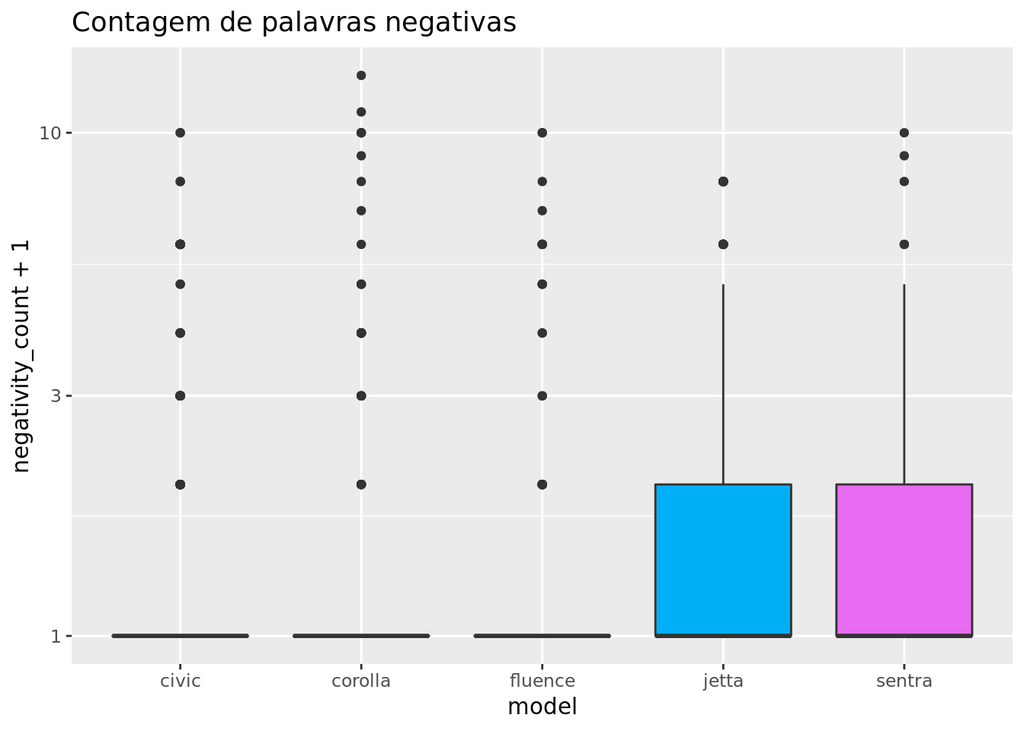

```r
df_filt %>%
  ggplot(aes(x=model,y=negativity_count+1,fill=model)) +
  geom_boxplot() +
  scale_y_log10() +
  ggtitle("Contagem de palavras negativas") +
  theme(legend.position = "none")
```

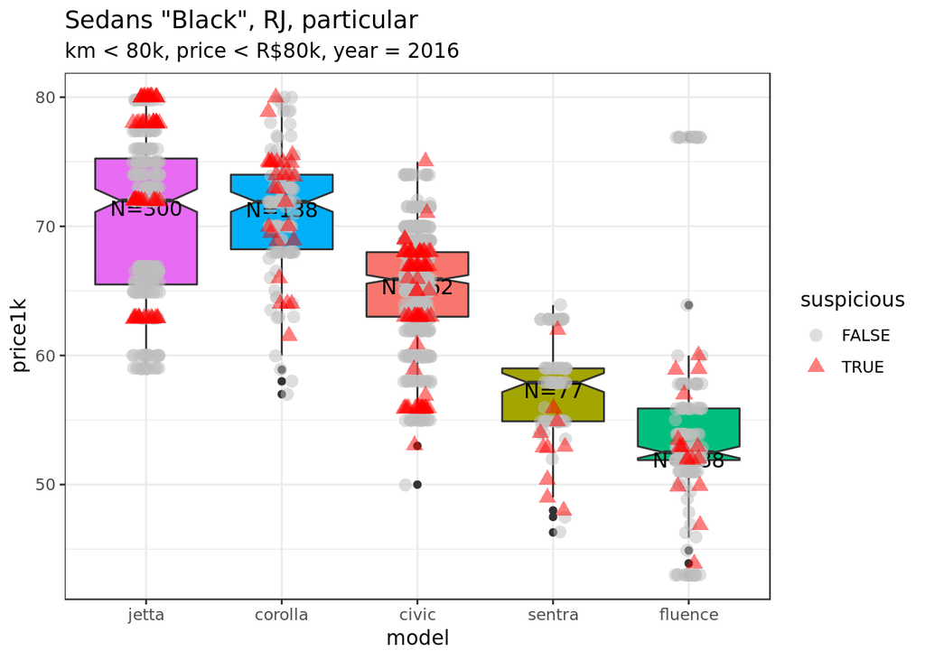

```r
df_filt %>%
  mutate(model=fct_reorder(model,price1k,.desc=T),
         suspicious=negativity_count>1) %>%
  arrange(suspicious) %>% # so true is drawn last
  #mutate(suspicious=as.factor(suspicious) %>% fct_inorder() %>% fct_rev()) %>%
  ggplot(aes(x=model,y=price1k,fill=brand)) +
  #geom_violin(alpha=.25) +
  geom_boxplot(notch = T, show.legend = F) +
  scale_fill_discrete(guide = "none") +
  stat_summary(fun.data = fun_length_y,
               geom = "text", vjust = 1,hjust=.5, size = 4) +
  geom_jitter(aes(color=suspicious,shape=suspicious),alpha=.5,width=.1,size=3) +
  scale_shape_manual(values=c(16,17)) +
  scale_colour_manual(values = c("gray","red")) +
  theme_bw() +
  ggtitle("Sedans \"Black\", RJ, particular",
          subtitle="km < 80k, price < R$80k, year = 2016")
```

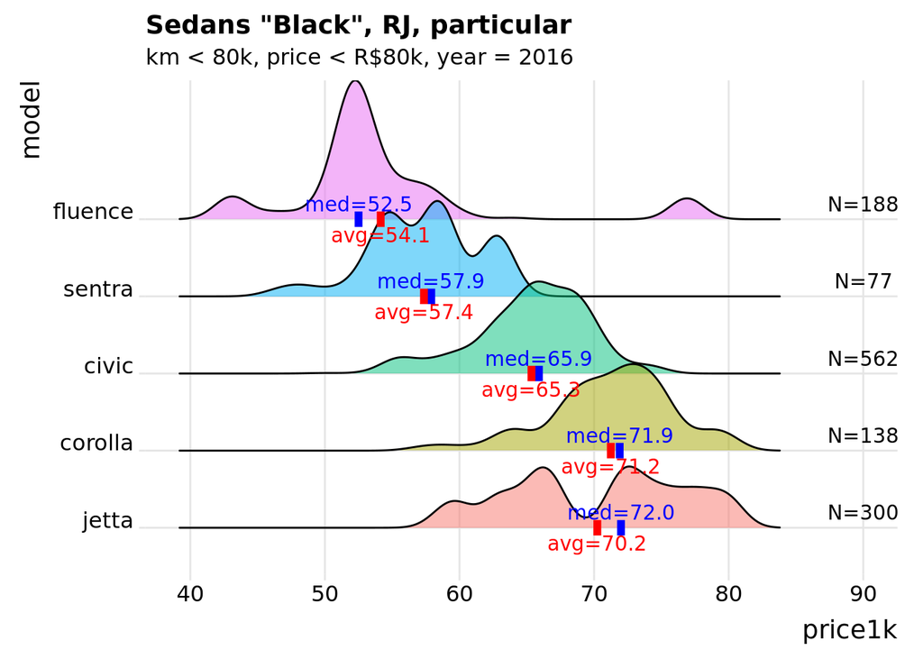

```r
df_filt_medians <- df_filt %>%
  group_by(model) %>%
  summarize(N=n(),
            price1k_median=median(price1k),
            price1k_mean=mean(price1k)) %>%
  arrange(desc(price1k_median)) %>%
  mutate(y=row_number())


df_filt %>%
  mutate(model=fct_reorder(model,price1k,.desc=T)) %>%
  ggplot(aes(price1k, model,fill=model)) +
  geom_density_ridges(alpha=.5) +
  geom_text(aes(x=90,y=y+.2,label=sprintf("N=%d",N)),
            data=df_filt_medians) +
  geom_segment(aes(x=price1k_median,y=y-.1,xend=price1k_median,yend=y+.1),
            data=df_filt_medians,color="blue",size=2) +
  geom_text(aes(x=price1k_median,y=y+.2,label=sprintf("med=%.1f",price1k_median)),
            data=df_filt_medians,color="blue") +
  geom_segment(aes(x=price1k_mean,y=y-.1,xend=price1k_mean,yend=y+.1),
               data=df_filt_medians,color="red",size=2) +
  geom_text(aes(x=price1k_mean,y=y-.2,label=sprintf("avg=%.1f",price1k_mean)),
            data=df_filt_medians,color="red") +
  theme_ridges() +
  ggtitle("Sedans \"Black\", RJ, particular",
          subtitle="km < 80k, price < R$80k, year = 2016") +
  theme(legend.position = "none")
```

Preço vs km

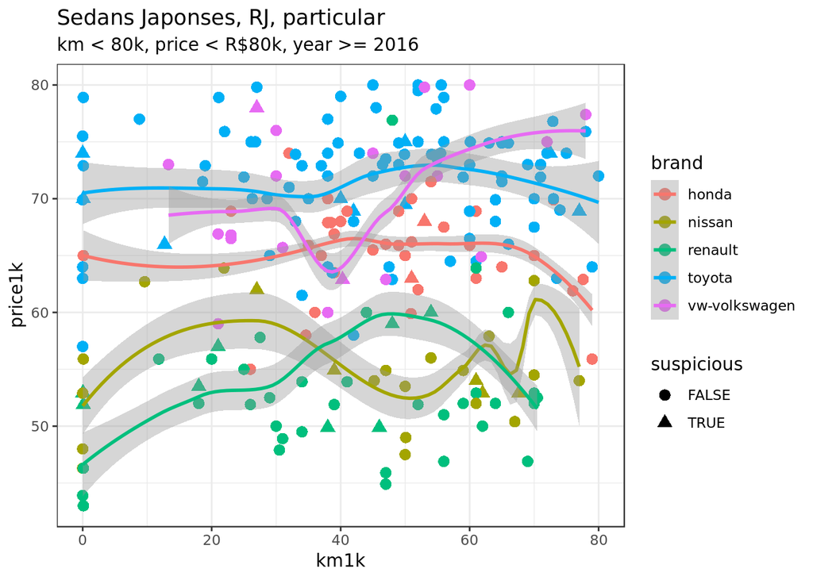

```r
df_filt %>%
  filter(!is.na(km1k),!is.na(price1k)) %>%
  mutate(suspicious=negativity_count>4) %>%
  ggplot(aes(km1k,price1k,color=brand,group=brand)) +
  geom_point(aes(shape=suspicious),size=3) +
  geom_smooth() +
  theme_bw() +
  ggtitle("Sedans Japonses, RJ, particular",
          subtitle="km < 80k, price < R$80k, year >= 2016")
```

Mesmo plot com ggvis (tooltips seems buggy, cannot yet add title)

```r
df_filt %>%
  ggvis(~km1k, ~price1k, fill=~brand) %>%
  group_by(brand) %>%
  layer_points() %>%
  # hangs
  # add_tooltip(function(df) "hello",on="click") %>%
  layer_smooths(stroke=~brand)
```

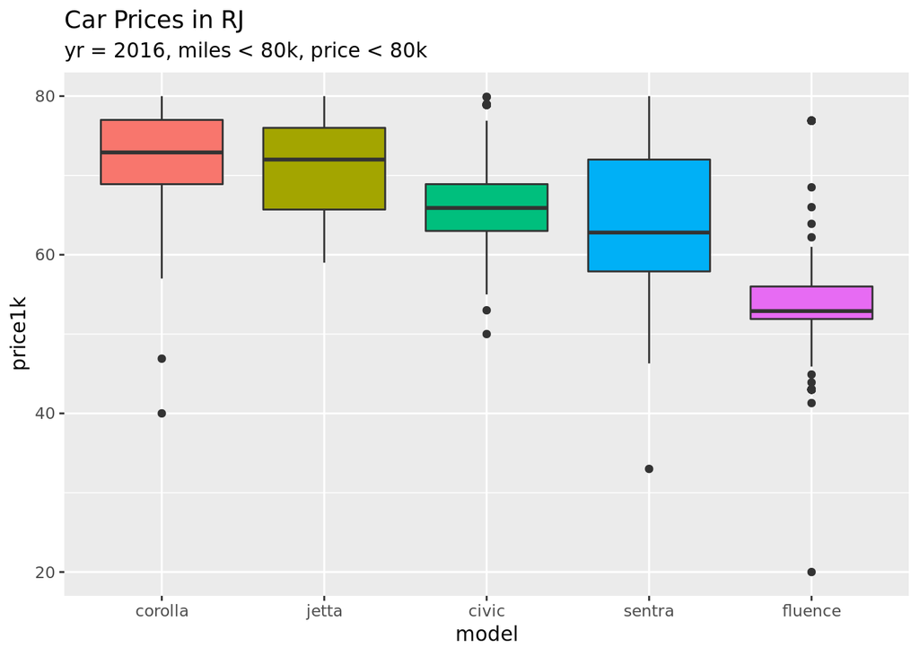

```r
advert_df_pp_clean_sentiment %>%
  mutate(model=model %>% fct_reorder(price1k,.desc=T)) %>%
  ggplot(aes(x=model,y=price1k,fill=model)) +
  geom_boxplot() +
  theme(legend.position = "none") +
  ggtitle("Car Prices in RJ",
          subtitle="yr = 2016, miles < 80k, price < 80k")
```